# EWS-FLI1 gene regulated genes

This document details the analysis of RNAseq data from different scenarios carried out in the Boulay 2017 paper at PMID28844694. I use the counts file provided in GSE94277 for this work.

## Setting up the environment

These are packages you will need for this notebook. For exact versions used, please refer to the session info at the bottom of this notebook.

```r
##########################################################################################
library('tidyverse')
library('ggplot2')
library('RColorBrewer')
library('ggrepel')
```

I want to set a base directory that we can use as a link to the directory where we will do most of the work. I use two directories here because the Workspace is what is pushed to GitHub and contains scripts and plot files, but the Repository is where more of the big data is stored that does not get pushed.

```r
##########################################################################################
generalDatasets = 'C:/Users/chughes/Documents/bccrc/projectsRepository/generalDatasets'
baseWorkspace = 'C:/Users/chughes/Documents/bccrc/projectsWorkspace/sorensenLab/relatedToDlg2'
baseRepository = 'C:/Users/chughes/Documents/bccrc/projectsRepository/sorensenLab/relatedToDlg2'
#generalDatasets = 'C:/Users/chris/OneDrive/Documents/bccrc/projectsRepository/generalDatasets'
#baseWorkspace = 'C:/Users/chris/OneDrive/Documents/bccrc/projectsWorkspace/sorensenLab/relatedToYbx1'
#baseRepository = 'C:/Users/chris/OneDrive/Documents/bccrc/projectsRepository/sorensenLab/relatedToYbx1'
```

## Data processing

Get the raw data.

```r
##########################################################################################
rna = read_tsv(paste(baseRepository, '/sequencing20201202_ewsFli1RnaSeqBoulayPmid28844694/GSE94277_counts_matrix.txt', sep = ''))
```

Make a plot for Dgl2.

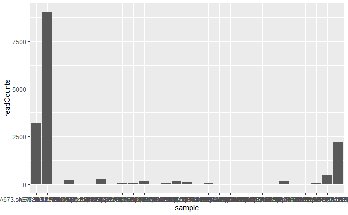

```r
##########################################################################################
goi = rna %>%
  filter(grepl('^DLG2$', gene)) %>%
  pivot_longer(cols = A673.shGFP.RNAseq:MSC5b.shBRG1.EWSFLI1.RNAseq, names_to = 'sample', values_to = 'readCounts')
##
ggplot(goi, aes(sample, readCounts)) +
  geom_col()
```

So that isn’t super useful. Maybe we should plot just the Ewing sarcoma genes first, then look at the MSCs.

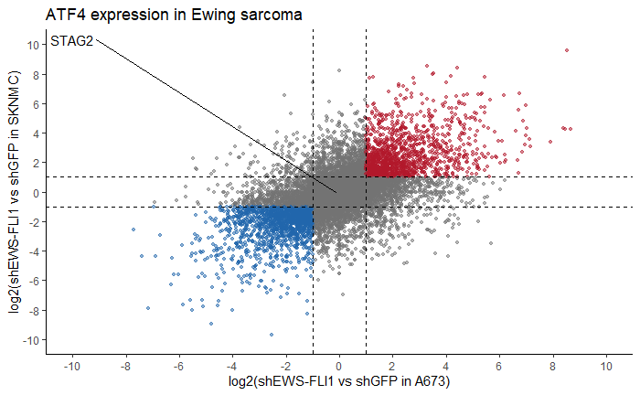

```r
##########################################################################################
goi = rna %>%
  dplyr::select(gene:SKNMC.shEWSFLI1.RNAseq) %>%
  filter(A673.shGFP.RNAseq >= 10 | A673.shEWSFLI1.RNAseq >= 10 | SKNMC.shGFP.RNAseq >= 10 | SKNMC.shEWSFLI1.RNAseq >= 10) %>%
  mutate(a673Fc = log2(A673.shEWSFLI1.RNAseq/A673.shGFP.RNAseq)) %>%
  mutate(SknmcFc = log2(SKNMC.shEWSFLI1.RNAseq/SKNMC.shGFP.RNAseq)) %>%
  filter(!is.na(a673Fc) & !is.na(SknmcFc) & !is.infinite(a673Fc) & !is.infinite(SknmcFc))
targetGenes = c('STAG2')
goi$pText = ifelse(goi$gene %in% targetGenes, goi$gene, '')
goi$pColors = ifelse(goi$a673Fc <= -1 & goi$SknmcFc <= -1, brewer.pal(8,'RdBu')[8],
                              ifelse(goi$a673Fc >= 1 & goi$SknmcFc >= 1, brewer.pal(8,'RdBu')[1],
                                     brewer.pal(8,'Greys')[6]))
##
ggplot(goi, aes(a673Fc, SknmcFc)) +
  geom_point(size = 1, color = goi$pColors, alpha = 0.5) +
  geom_text_repel(label = goi$pText) +
  labs(x = 'log2(shEWS-FLI1 vs shGFP in A673)', y = 'log2(shEWS-FLI1 vs shGFP in SKNMC)', title = 'ATF4 expression in Ewing sarcoma') +
  geom_vline(xintercept = c(-1,1), linetype = 'dashed') +
  geom_hline(yintercept = c(-1,1), linetype = 'dashed') +
  scale_y_continuous(limits = c(-10,10), breaks = seq(-10,10,2)) +
  scale_x_continuous(limits = c(-10,10), breaks = seq(-10,10,2)) +
  theme_classic()
ggsave(paste(baseRepository, '/sequencing20201202_ewsFli1RnaSeqBoulayPmid28844694/scatter_stag2RnaExpressionShEwsfli1.pdf', sep = ''),
       height = 4, width = 4, useDingbats = FALSE)
```

Now we can show the MSC data.

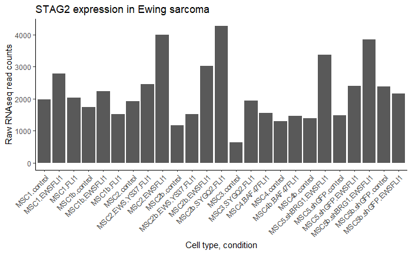

```r
##########################################################################################
goi = rna %>%
  filter(grepl('^STAG2$', gene)) %>%
  pivot_longer(cols = MSC1.control.RNAseq:MSC5b.shBRG1.EWSFLI1.RNAseq, names_to = 'sample', values_to = 'readCounts') %>%
  mutate(condition = sub('(.*)\\.RNAseq$', '\\1', sample))
##
ggplot(goi, aes(condition, readCounts)) +
  geom_col() +
  labs(x = 'Cell type, condition', y = 'Raw RNAseq read counts', title = 'STAG2 expression in Ewing sarcoma') +
  theme_classic() +
  theme(axis.text.x = element_text(angle = 45, hjust = 1))
ggsave(paste(baseRepository, '/sequencing20201202_ewsFli1RnaSeqBoulayPmid28844694/barplot_stag2RnaExpressionAllConditions.pdf', sep = ''),
       height = 4, width = 6, useDingbats = FALSE)
```

This is kind of hard to look at, so let’s try to reshape it a bit and plot ratios relative to controls.

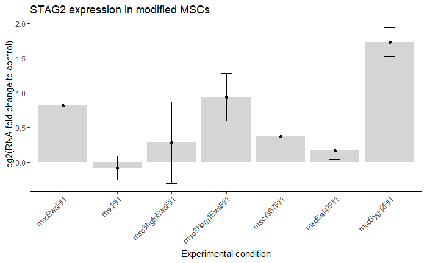

```r
##########################################################################################
goi = rna %>%
  filter(grepl('^STAG2$', gene)) %>%
  mutate(mscEwsFli1.1 = MSC1.EWSFLI1.RNAseq / MSC1.control.RNAseq) %>%
  mutate(mscEwsFli1.2 = MSC1b.EWSFLI1.RNAseq / MSC1b.control.RNAseq) %>%
  mutate(mscEwsFli1.3 = MSC2.EWSFLI1.RNAseq / MSC2.control.RNAseq) %>%
  mutate(mscEwsFli1.4 = MSC2b.EWSFLI1.RNAseq / MSC2b.control.RNAseq) %>%
  mutate(mscFli1.1 = MSC1.FLI1.RNAseq / MSC1.control.RNAseq) %>%
  mutate(mscFli1.2 = MSC1b.FLI1.RNAseq / MSC1b.control.RNAseq) %>%
  mutate(mscYs37Fli1.1 = MSC2.EWS.YS37.FLI1.RNAseq / MSC2.control.RNAseq) %>%
  mutate(mscYs37Fli1.2 = MSC2b.EWS.YS37.FLI1.RNAseq / MSC2b.control.RNAseq) %>%
  mutate(mscSygq2Fli1.1 = MSC2b.SYGQ2.FLI1.RNAseq / MSC2b.control.RNAseq) %>%
  mutate(mscSygq2Fli1.2 = MSC3.SYGQ2.FLI1.RNAseq / MSC3.control.RNAseq) %>%
  mutate(mscBaf47Fli1.1 = MSC4.BAF47FLI1.RNAseq / MSC4.control.RNAseq) %>%
  mutate(mscBaf47Fli1.2 = MSC4b.BAF47FLI1.RNAseq / MSC4b.control.RNAseq) %>%
  mutate(mscShgfpEwsFli1.1 = MSC5.shGFP.EWSFLI1.RNAseq / MSC5.shGFP.control.RNAseq) %>%
  mutate(mscShgfpEwsFli1.2 = MSC5b.shGFP.EWSFLI1.RNAseq / MSC5b.shGFP.control.RNAseq) %>%
  mutate(mscShbrg1EwsFli1.1 = MSC5.shBRG1.EWSFLI1.RNAseq / MSC5.shGFP.control.RNAseq) %>%
  mutate(mscShbrg1EwsFli1.2 = MSC5b.shBRG1.EWSFLI1.RNAseq / MSC5b.shGFP.control.RNAseq) %>%
  dplyr::select(gene, mscEwsFli1.1:mscShbrg1EwsFli1.2) %>%
  pivot_longer(cols = mscEwsFli1.1:mscShbrg1EwsFli1.2, names_to = 'replicate', values_to = 'readsRelativeToControl') %>%
  mutate(sampleName = sub('(.*)\\.[0-9]$', '\\1', replicate)) %>%
  mutate(log2Relative = log2(readsRelativeToControl)) %>%
  dplyr::select(sampleName, log2Relative) %>%
  group_by(sampleName) %>%
  summarise(across(starts_with('log2'), list(mean = mean, sd = sd))) %>%
  mutate(sampleName = factor(sampleName, levels = c('a673EwsFli1','sknmcEwsFli1',
                                                   'mscEwsFli1','mscFli1',
                                                   'mscShgfpEwsFli1','mscShbrg1EwsFli1',
                                                   'mscYs37Fli1','mscBaf47Fli1','mscSygq2Fli1')))
##
ggplot(goi, aes(sampleName, log2Relative_mean)) +
  geom_point() +
  geom_bar(stat = 'identity', alpha = 0.25) +
  geom_errorbar(aes(ymin=log2Relative_mean-log2Relative_sd, ymax=log2Relative_mean+log2Relative_sd), width=.2, position=position_dodge(.9)) +
  labs(x = 'Experimental condition', y = 'log2(RNA fold change to control)', title = 'STAG2 expression in modified MSCs') +
  theme_classic() +
  theme(axis.text.x = element_text(angle = 45, hjust = 1))
ggsave(paste(baseRepository, '/sequencing20201202_ewsFli1RnaSeqBoulayPmid28844694/barplot_stag2RnaExpressionMscOnlyConditions.pdf', sep = ''),
       height = 4, width = 4, useDingbats = FALSE)
```

[session information not shown]